# scat - scRNA-seq analysis toolkit

Compiled: 七月 14, 2020

### 安装R包

```r
# 安装开发工具包
if (!require("devtools")) {
    install.packages("devtools")
    library(devtools)
}
# 从GitHub上安装scat包
if (!require("scat")) {
    install_github("ergazee/scat/Rpackage")
    library(sctk)
}
```

**这样的写法可以先检查R包是否安装，已安装则直接调用，否则先安装再调用。**

### 数据准备

导入表达矩阵

```r
mat1 <- read.table("..//extdata//refData1.txt", header = TRUE, row.names = 1)
mat2 <- read.table("..//extdata//refData2.txt", header = TRUE, row.names = 1)
mat3 <- read.table("..//extdata//Data1.txt", header = TRUE, row.names = 1)
mat4 <- read.table("..//extdata//Data2.txt", header = TRUE, row.names = 1)
```

导入参考数据集的标签信息

```r
refLabel1 <- read.table("..//extdata//refLabel1.txt", header = TRUE, row.names = 1)
refLabel1$refLabel <- refLabel1$CellType

refLabel2 <- read.table("..//extdata//refLabel2.txt", header = TRUE, row.names = 1)
refLabel2$refLabel <- refLabel2$CellType
```

分别将实验数据集和参考数据集处理为seurat对象，然后保存为data.list

```r
refData1 <- datainput(mat = mat1, name = "Ref_data1", refLabel = refLabel1)
refData2 <- datainput(mat = mat2, name = "Ref_data2", refLabel = refLabel2)

data1 <- datainput(mat = mat3, name = "Query_data1")
data2 <- datainput(mat = mat4, name = "Query_data2")

data.list <- list(data1, data2, refData1, refData2)
rm(list = setdiff(ls(), "data.list"))
```

### 标准整合流程

细胞数据质控

```r
# 计算线粒体RNA比例，可视化细胞基因数，pdf文件保存在工作路径中
for (i in 1:length(data.list)) {
    data.list[[i]][["percent.mt"]] <- PercentageFeatureSet(data.list[[i]], pattern = "^MT-")
    pdf(as.character(paste("data_quality", i, ".pdf", sep = "_")), width = 10, height = 6)
    print(VlnPlot(data.list[[i]], features = c("nFeature_RNA", "nCount_RNA", "percent.mt"), ncol = 3))
    dev.off()
}

# 细胞质控
for (i in 1:length(data.list)) {
    data.list[[i]] <- subset(data.list[[i]], subset = nFeature_RNA > 200 & percent.mt < 10)
    data.list[[i]] <- NormalizeData(data.list[[i]], verbose = FALSE)
}

# 输出质控后的细胞数量
cell_count = sapply(data.list, ncol)
message("cell count: \n", paste("data", seq(1:length(cell_count)), ": ", cell_count, "\n", sep = ""))
```

### 遍历寻优,返回的data.integrated即为最优参数结果

```r
data.integrated <- ptuner(data.list = data.list, Normalize_Method = "Standard", Dims = 30, Nmin = 2000, Nmax = 3000, Nstep = 1000,
    Rmin = 0.5, Rmax = 0.8, Rstep = 0.1)
```

**若选择SCT流程，则Normalize_Method参数应设置为SCT**

### 不同参数组合下参考数据集的标签一致性

```r
consistency
```

|  | 0.5 | 0.6 | 0.7 | 0.8 |
| --- | --- | --- | --- | --- |
| 2000 | 0.8938 | 0.8967 | 0.9055 | 0.9077 |
| 3000 | 0.8982 | 0.8989 | 0.8982 | 0.8982 |

### Sankeyplot可以可视化细胞标签对应关系，展示细胞类型鉴定过程

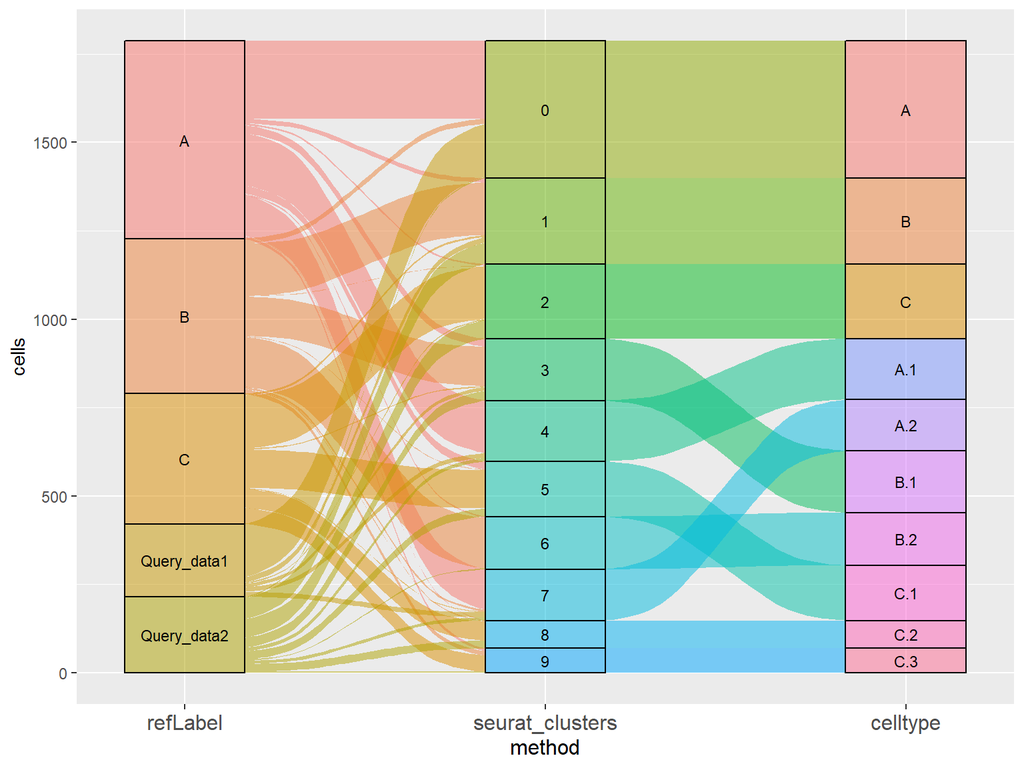

```r
Sankeyplot(data.integrated, "refLabel", "seurat_clusters", "celltype")
```

### 可视化亚群间相关系数

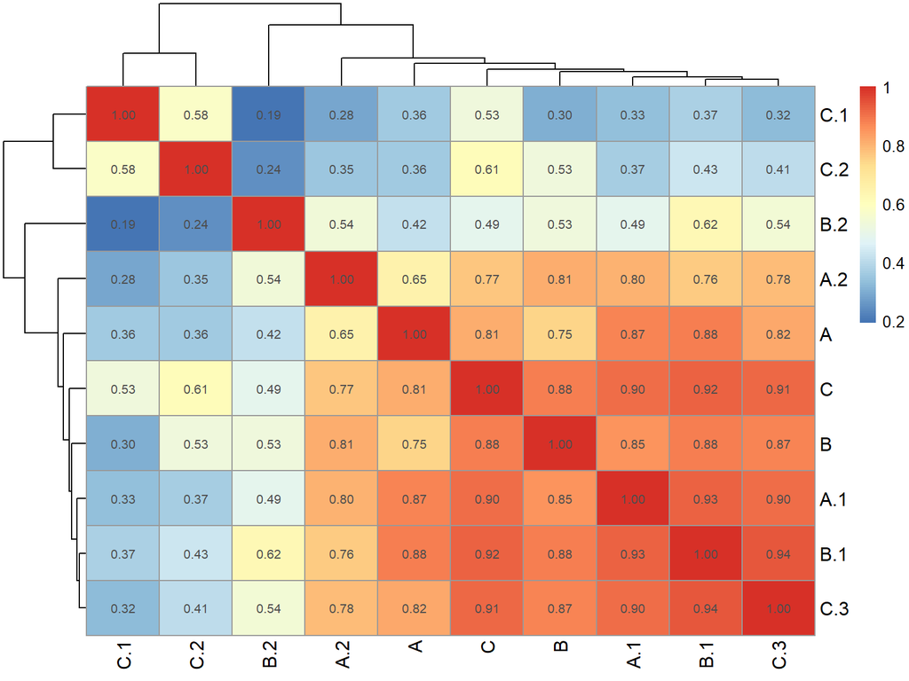

```r
av.exp <- AverageExpression(data.integrated)$RNA
cor.exp <- as.data.frame(cor(av.exp, method = "pearson"))
pheatmap(cor.exp, display_numbers = TRUE, fontsize_row = 12, fontsize_col = 12, angle_col = 90)
```

**method参数可设置为pearson或spearman等**

### Barplot可以可视化不同细胞亚群间的属性分布，如基因数

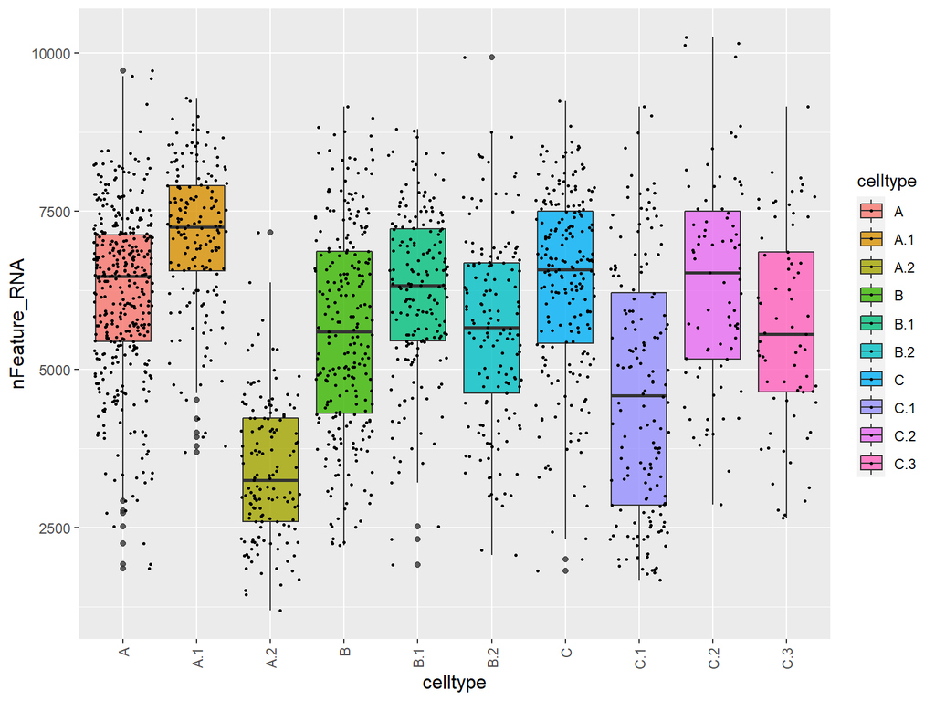

```r
Barplot(data.integrated, "celltype", "nFeature_RNA")
```

### 提取特定样本，计算各亚群的显著上调markers

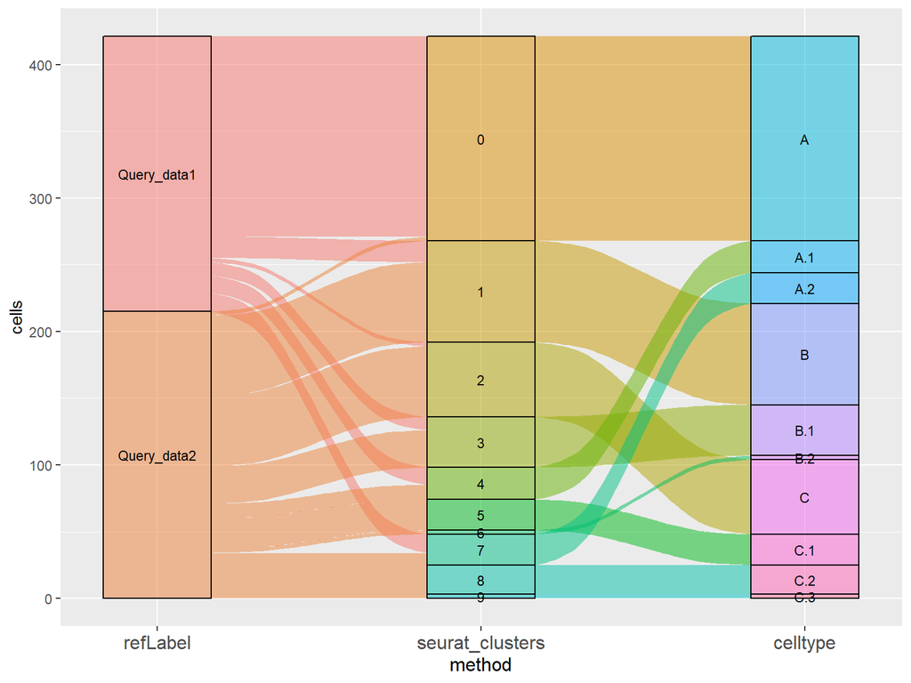

```r
cells.use <- colnames(data.integrated)[which(data.integrated[[]]["type"] == "Query_data1" | data.integrated[[]]["type"] ==
    "Query_data2")]
data.new <- subset(data.integrated, cells = cells.use)
Sankeyplot(data.new, "refLabel", "seurat_clusters", "celltype")
```

```r
data.markers <- FindAllMarkers(data.new, only.pos = TRUE, min.pct = 0.2, logfc.threshold = 0.2)
```

### 绘制亚群间markers的韦恩图，png文件保存在工作路径中

```r
markers <- list(A = data.markers[data.markers$cluster == "A", ]$gene, B = data.markers[data.markers$cluster == "B", ]$gene,
    C = data.markers[data.markers$cluster == "C", ]$gene)
VN3(markers, "A_B_C.png")
```

**VN2，VN3，VN4，VN5函数对应不同的亚群数量**

### 绘制各亚群的topN marker

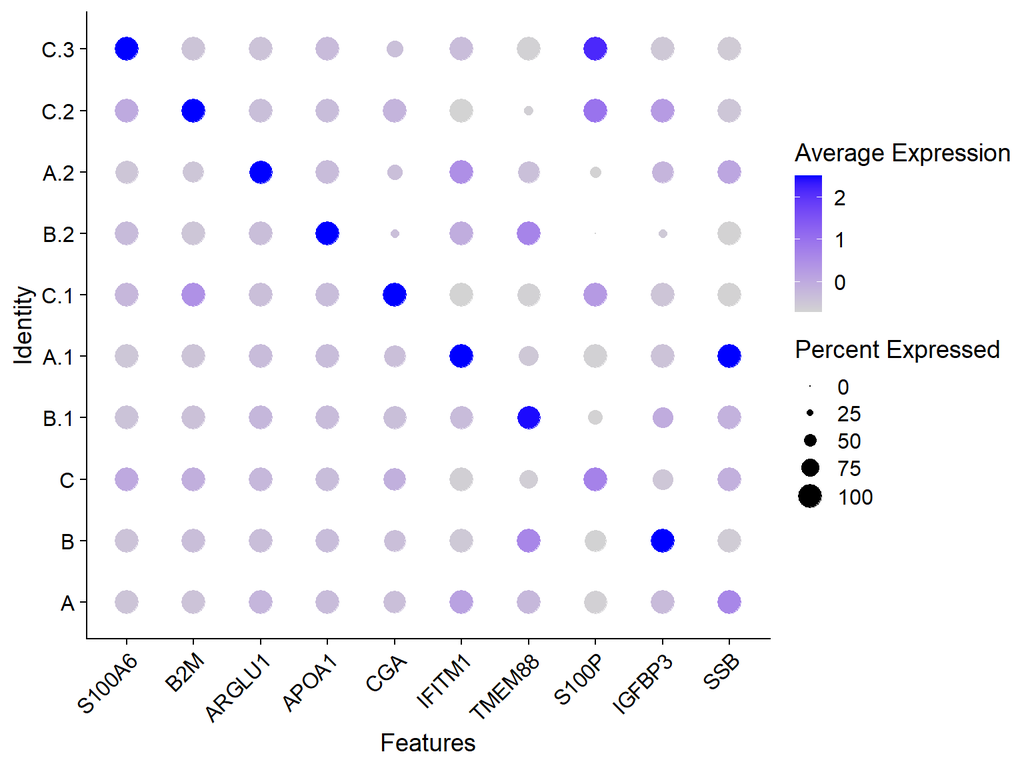

```r
top2 <- data.markers %>% group_by(cluster) %>% top_n(n = 1, wt = avg_logFC)
DotPlot(data.new, features = unique(top2$gene)) + RotatedAxis()
```

### 绘制特定基因在样本中的表达分布

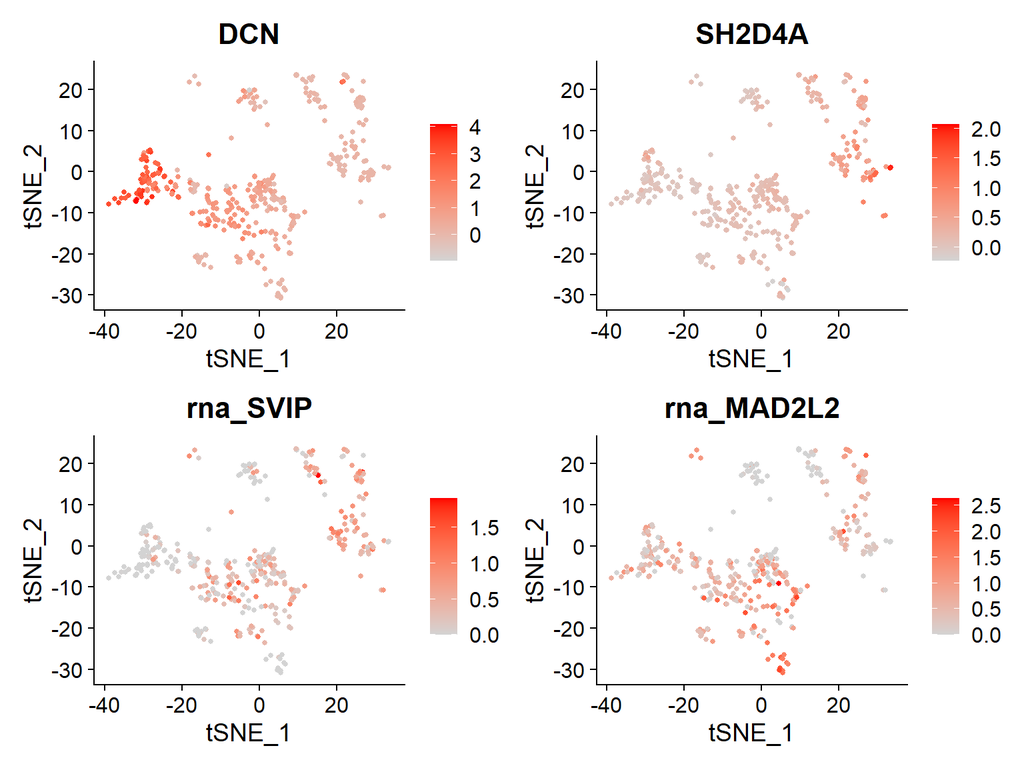

```r
genes <- c("DCN", "SH2D4A", "SVIP", "MAD2L2")
FeaturePlot(data.new, features = genes, reduction = "tsne", cols = c("lightgrey", "red"))
```

### 对各亚群的markers进行富集分析，图表文件保存在工作路径中

```r
library(org.Hs.eg.db)
Enrich(data.markers, database = "KEGG", orgdb = "org.Hs.eg.db", organism = "hsa")
```

**database参数可设置为GO或KEGG**

### 保存Rda,用于后续分析

```r
save(data.new, file = "test.Rda")
```